# 21_DQN

**Deep Q-Learning**

By Prof. Seungchul Lee  
http://iai.postech.ac.kr/  
Industrial AI Lab at POSTECH

Source

- By David Silver's RL Course at UCL
- By Prof. Zico Kolter at CMU

Table of Contents

# 1. Deep Q-Learning (DQN)

Value iteration algorithm: use Bellman equation as an iterative update

$$ Q_{k+1}(s,a) \; \leftarrow \; \mathbb{E}_{s' \sim P\left(s'\mid s,a\right)} \left[ R(s) + \gamma \max_{a'} Q_{k}\left(s',a'\right) \right] $$

$Q_k$ will converge to $Q_*$ as $k$ goes to $\infty$

## 1.1. What is the problem with this?

- Not scalable. Must compute tabular $Q(s,a)$ for every state-action pair. If state is for instance current game state pixels, computationally infeasible to compute for entire state space !
  - too many states to visit them all in training
  - too many states to hold the Q-table in memory
- States in Tetris: naive board configuration + shape of the falling piece $\sim 10^{60}$ states !!!

[figure not shown]

- Solution: use a function approximator to estimate $Q(s,a)$
  - learn about some small number of training states from experience
  - generalize that experience to new, similar situations

## 1.2. Approximate Q-Learning

Instead of a table, we have a parameterized Q function: $Q_{\omega}(s,a) \approx Q_*(s,a)$

- can be a linear function in features

$$Q_{\omega}(s,a) = \omega_0 f_0(s,a) + \omega_1 f_1(s,a) + \cdots + \omega_n f_n(s,a)$$

- or a complicated neural network $\rightarrow$ (Deep Q-learning Network)

Learning rule:

- transition = $\left(s,a,r,s' \right)$
- remember:

$$\text{target}\left(s'\right) = R(s) + \gamma \max_{a'}Q_{\omega}{\left(s',a'\right)}$$

$$Q_{k+1}(s,a) \; \leftarrow \; Q_k(s,a) + \alpha \; \underbrace{\left(\text{target}\left(s'\right) - Q_k(s,a) \right)}_{\text{difference}}$$

- difference

$$ \text{difference} = \left[R(s) + \gamma \max_{a'}Q_{\omega}{\left(s',a'\right)} \right] - Q_{\omega}{\left(s,a\right)}$$

- loss function by mean-squared error in Q-value

$$\ell(\omega) = \left[ \frac{1}{2} \left(\text{target}\left(s'\right) - Q_{\omega}(s,a) \right)^2 \right]$$

- GD update:

$$ \begin{align*} \omega_{k+1} \; &\leftarrow \; \omega_k - \alpha \; \nabla_{\omega} \ell(\omega) \qquad \qquad \implies \text{Deep Learning Framework}\\ \\ \; &\leftarrow \; \omega_k - \alpha \; \nabla_{\omega} \left[ \frac{1}{2} \left(\text{target}\left(s'\right) - Q_{\omega}(s,a)\right)^2 \right] \\ \\ \; &\leftarrow \; \omega_k + \alpha \; \left[ \left(\text{target}\left(s'\right) - Q_{\omega}(s,a)\right) \right] \nabla_{\omega} Q_{\omega}(s,a) \end{align*} $$

## 1.3. Linear Function Approximator

$$Q_{\omega}(s,a) = \omega_0 f_0(s,a) + \omega_1 f_1(s,a) + \cdots + \omega_n f_n(s,a)$$

- Exact $Q$

$$Q(s,a) \;\leftarrow \; Q(s,a) + \alpha \, [\text{difference}] $$

- Approximate $Q$

$$\omega_i \;\leftarrow\; \omega_i + \alpha \, [\text{difference}] \, f_i(s,a)$$

**Example: linear regression**

$$\ell = \frac{1}{2} \left(y - \hat{y} \right)^2$$

- difference

$$y - \hat{y} = y - \left(\omega_0 f_0(x) + \omega_1 f_1(x) + \cdots + \omega_n f_n(x)\right) = \underbrace{y}_{\text{target}} - \underbrace{\sum_i \omega_i f_i(x)}_{\text{prediction}} $$

- For one point $x$

$$ \begin{align*} \frac{\partial \ell(\omega)}{\partial \omega_k} &= - \left(y - \sum_i \omega_i f_i(x) \right)f_k(x)\\ \\ \omega_k \;&\leftarrow\; \omega_i + \alpha \left(y - \sum_i \omega_i f_i(x) \right)f_k(x) \\ \\ \omega_k \;&\leftarrow\; \omega_i + \alpha \, \left[\text{difference} \right] \,f_k(x) \end{align*}$$

## 1.4. Deep Q-Networks (DQN)

DQN method (Q-learning with deep network as Q function approximator) became famous in 2013 for learning to play a wide variety of Atari games better than humans.

- Deep Mind, 2015
  - Used a deep learning network to represent Q

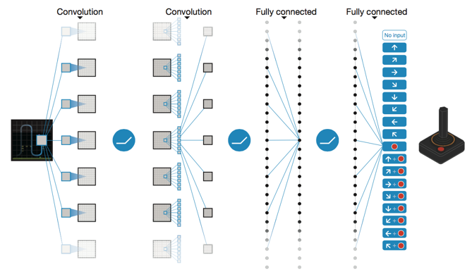

```python
%%html
<center><iframe src="https://www.youtube.com/embed/V1eYniJ0Rnk?rel=0"
width="560" height="315" frameborder="0" allowfullscreen></iframe></center>
```

[video not shown]

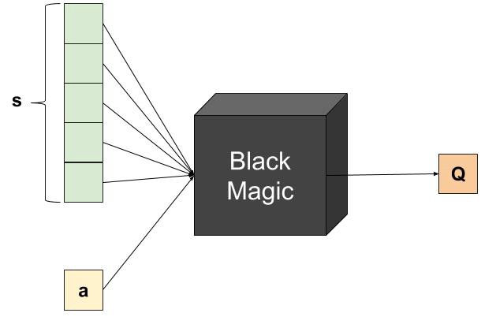

- Better DQN

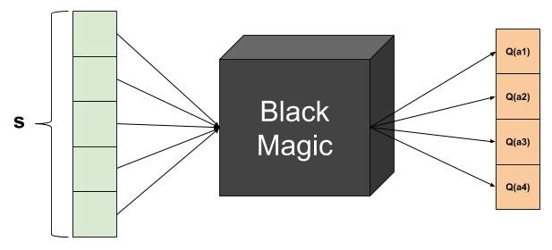

# 2. Q Network with Gym Environment

```python
# !pip install gym
```

```python
import numpy as np
import matplotlib.pyplot as plt
import tensorflow as tf

import random
import gym
```

```python
env = gym.make('CartPole-v1')
```

```python
n_input = env.observation_space.shape[0] # 4
n_actions = env.action_space.n # 2
n_output = n_actions

n_hidden1 = 100
n_hidden2 = 50
```

```python
x = tf.placeholder(tf.float32, [None, n_input])
y = tf.placeholder(tf.float32, [None, n_output])
```

```python
weights = {
    'hidden1' : tf.Variable(tf.random_normal([n_input, n_hidden1], stddev = 0.01)),
    'hidden2' : tf.Variable(tf.random_normal([n_hidden1, n_hidden2], stddev = 0.01)),
    'output' : tf.Variable(tf.random_normal([n_hidden2, n_output], stddev = 0.01))
}

biases = {
    'hidden1' : tf.Variable(tf.random_normal([n_hidden1], stddev = 0.01)),
    'hidden2' : tf.Variable(tf.random_normal([n_hidden2], stddev = 0.01)),
    'output' : tf.Variable(tf.random_normal([n_output], stddev = 0.01))
}
```

```python
def Qnet(x, weights, biases):
    hidden1 = tf.add(tf.matmul(x, weights['hidden1']), biases['hidden1'])
    hidden1 = tf.nn.relu(hidden1)

    hidden2 = tf.add(tf.matmul(hidden1, weights['hidden2']), biases['hidden2'])
    hidden2 = tf.nn.relu(hidden2)

    output = tf.add(tf.matmul(hidden2, weights['output']), biases['output'])
    return output
```

```python
Qpred = Qnet(x, weights, biases)
loss = tf.reduce_mean(tf.square(y - Qpred))

LR = 0.001
optm = tf.train.AdamOptimizer(LR).minimize(loss)
```

```python
sess = tf.Session()
init = tf.global_variables_initializer()
sess.run(init)
```

```python
gamma = 0.9

for episode in range(801):

    done = False
    state = env.reset()

    count = 0

    while not done:

        count += 1
        state = np.reshape(state, [1, n_input])
        Q = sess.run(Qpred, feed_dict = {x: state})

        # Exploration vs. Exploitation for action
        epsilon = 0.1
        if np.random.uniform() < epsilon:
            a = env.action_space.sample()
        else:
            a = np.argmax(Q)

        # next state and reward
        next_state, reward, done, _ = env.step(a)

        if done:
            reward = -200
            Q[0][a] = reward

        else:
            next_state = np.reshape(next_state, [1, n_input])
            next_Q = sess.run(Qpred, feed_dict = {x: next_state})
            Q[0][a] = reward + gamma*np.max(next_Q)

        sess.run(optm, feed_dict = {x: state, y: Q})

        state = next_state

    if episode % 100 == 0:
        print("Episode: {} steps: {}".format(episode, count))

env.close()
```

```
Episode: 0 steps: 10
Episode: 100 steps: 55
Episode: 200 steps: 32
Episode: 300 steps: 51
Episode: 400 steps: 61
Episode: 500 steps: 77
Episode: 600 steps: 109
Episode: 700 steps: 208
Episode: 800 steps: 228
```

```python
state = env.reset()

done = False

while not done:
    env.render()

    state = np.reshape(state, [1, n_input])
    Q = sess.run(Qpred, feed_dict = {x: state})
    action = np.argmax(Q)

    next_state, reward, done, _ = env.step(action)
    state = next_state

env.close()
```

```python
sess.close()
```

# 3. DQN with Gym Environment

```python
import numpy as np
import matplotlib.pyplot as plt
import tensorflow as tf

import random
from collections import deque

import gym
%matplotlib inline
```

```python
env = gym.make('CartPole-v1')
```

```python
n_input = env.observation_space.shape[0] # 4
n_actions = env.action_space.n # 2
n_output = n_actions

n_hidden1 = 100
n_hidden2 = 50
```

```python
x = tf.placeholder(tf.float32, [None, n_input])
y = tf.placeholder(tf.float32, [None, n_output])
```

```python
weights = {
    'hidden1' : tf.Variable(tf.random_normal([n_input, n_hidden1], stddev = 0.01)),
    'hidden2' : tf.Variable(tf.random_normal([n_hidden1, n_hidden2], stddev = 0.01)),
    'output' : tf.Variable(tf.random_normal([n_hidden2, n_output], stddev = 0.01))
}

biases = {
    'hidden1' : tf.Variable(tf.random_normal([n_hidden1], stddev = 0.01)),
    'hidden2' : tf.Variable(tf.random_normal([n_hidden2], stddev = 0.01)),
    'output' : tf.Variable(tf.random_normal([n_output], stddev = 0.01))
}
```

```python
def DQN(x, weights, biases):
    hidden1 = tf.add(tf.matmul(x, weights['hidden1']), biases['hidden1'])
    hidden1 = tf.nn.relu(hidden1)

    hidden2 = tf.add(tf.matmul(hidden1, weights['hidden2']), biases['hidden2'])
    hidden2 = tf.nn.relu(hidden2)

    output = tf.add(tf.matmul(hidden2, weights['output']), biases['output'])
    return output
```

```python
Qpred = DQN(x, weights, biases)
loss = tf.reduce_mean(tf.square(y - Qpred))

LR = 0.001
optm = tf.train.AdamOptimizer(LR).minimize(loss)
```

```python
sess = tf.Session()
init = tf.global_variables_initializer()
sess.run(init)
```

```python
replay_buffer = []
n_buffer = 5000
n_batch = 10

gamma = 0.9

for episode in range(2001):

    done = False
    state = env.reset()

    count = 0

    while not done:

        count += 1
        Q = sess.run(Qpred, feed_dict = {x: np.reshape(state, [1, n_input])})

        # Exploration vs. Exploitation for action
        epsilon = 0.1
        if np.random.uniform() < epsilon:
            action = env.action_space.sample()
        else:
            action = np.argmax(Q)

        next_state, reward, done, _ = env.step(action)

        if done:
            reward = -200
            #next_state = np.zeros(state.shape)

        replay_buffer.append([state, action, reward, next_state, done])

        if len(replay_buffer) > n_buffer:
            replay_buffer.pop(0)

        state = next_state

    if episode % n_batch == 1:

        for _ in range(50):

            if len(replay_buffer) < n_batch:
                break

            minibatch = random.sample(replay_buffer, n_batch)

            x_stack = np.empty(0).reshape(0, n_input)
            y_stack = np.empty(0).reshape(0, n_output)

            for state, action, reward, next_state, done in minibatch:

                Q = sess.run(Qpred, feed_dict = {x: np.reshape(state, [1, n_input])})

                if done:
                    Q[0][action] = reward
                else:
                    next_Q = sess.run(Qpred, feed_dict = {x: np.reshape(next_state, [1, n_input])})
                    Q[0][action] = reward + gamma*np.max(next_Q)

                x_stack = np.vstack([x_stack, state])
                y_stack = np.vstack([y_stack, Q])

            sess.run(optm, feed_dict = {x: x_stack, y: y_stack})

    if episode % 200 == 1:
        print("Episode: {} steps: {}".format(episode, count))

env.close()
```

```
Episode: 1 steps: 9
Episode: 201 steps: 35
Episode: 401 steps: 43
Episode: 601 steps: 42
Episode: 801 steps: 39
Episode: 1001 steps: 67
Episode: 1201 steps: 64
Episode: 1401 steps: 101
Episode: 1601 steps: 102
Episode: 1801 steps: 103
```

```python
state = env.reset()

done = False

while not done:
    env.render()

    state = np.reshape(state, [1, n_input])
    Q = sess.run(Qpred, feed_dict = {x: state})
    action = np.argmax(Q)

    next_state, reward, done, _ = env.step(action)
    state = next_state

env.close()
```

```python
sess.close()
```

# 4. Other Tutorials

- Sutton and Barto book
  - http://incompleteideas.net/book/the-book-2nd.html
- David Silver's RL Course
  - http://www0.cs.ucl.ac.uk/staff/d.silver/web/Teaching.html
- Berkeley Deep Reinforcement Learning Course
  - http://rail.eecs.berkeley.edu/deeprlcourse/
- Deep RL Bootcamp lectures
  - https://sites.google.com/view/deep-rl-bootcamp/lectures

```python
%%javascript
$.getScript('https://kmahelona.github.io/ipython_notebook_goodies/ipython_notebook_toc.js')
```